# Construcción de la red

Se construye una red de oncogenes a partir del material proporcionado en el artículo en forma de archivo excel.

En primer lugar cargamos (instalamos previamente) las librerías necesarias.

```r
#install.packages("igraph")
#install.packages("readxl")
library(igraph)
library(readxl)
```

Ahora leemos los datos a partir del documento Excel y construimos el grafo.

```r
aristas <- read_excel("./Dataset1.xlsx",
                    sheet = "WeigthedNetwork")
nodos <- read_excel("./Dataset1.xlsx",
                    sheet = "NetworkNodes")
grafo <-
  graph_from_data_frame(d = aristas,  directed=F, vertices = nodos)
```

Estudiamos y visualizamos el grafo. Se trata de una estructura con 177 nodos y 15576 aristas. El grafo es ponderado y no dirigido.

```r
V(grafo)
```

```
+ 177/177 vertices, named, from bbd96a5:
  [1] KRT19     EPCAM     TACSTD2   MAL2      TGFBI     AGR2      VIM       GJA1
  [9] SRGN      IGFBP7    SPP1      CAV1      DKK1      C19orf33  UCHL1     SPARC
 [17] TFPI2     S100P     DSP       CTGF      ALDH1A1   MIR205HG  BASP1     IGFBP3
 [25] SPINT2    AKR1C3    FSTL1     MGST1     ANXA1     TM4SF1    AKR1C2    ANXA3
 [33] RPS4Y1    ESRP1     AMIGO2    NNMT      CAV2      COL1A2    KRT7      IFI27
 [41] TSPAN8    VAMP8     HSPA1A    LCN2      CTHRC1    S100A2    RAB25     SRPX
 [49] PLAC8     MMP1      SERPINB5  PLS3      ARHGDIB   EFEMP1    LUM       MYOF
 [57] HLA-DRA   CYR61     ALDH1A3   LGALS3    CSTA      COL6A3    AKR1B10   SERPINE1
 [65] COL5A2    GNG11     EMP1      GDF15     PLAT      GTSF1     GPRC5A    TNC
 [73] SPOCK1    MEST      PTX3      TUBB6     SFN       CEACAM6   HLA-DPA1  SERPINE2
+ ... omitted several vertices
```

```r
E(grafo)
```

```
+ 15576/15576 edges from bbd96a5 (vertex names):
 [1] COL4A1  --COL4A2   CAV1    --CAV2     EPCAM   --SPINT2   EPCAM   --MAL2
 [5] ESRP1   --RAB25    AKR1C2  --AKR1C1   EPCAM   --RAB25    MAL2    --SPINT2
 [9] C19orf33--SFN      EPCAM   --ESRP1    CYR61   --GPX8     SPINT2  --RAB25
[13] C19orf33--GPRC5A   SPINT2  --ESRP1    MAL2    --RAB25    MAL2    --ESRP1
[17] MAL2    --DSP      KRT19   --MAL2     C19orf33--ANXA3    MAL2    --SFN
[21] ESRP1   --GALNT3   EPCAM   --DSP      HLA-DRA --HLA-DPA1 MYOF    --GPRC5A
[25] EPCAM   --SFN      CAV2    --MYOF     RAB25   --GALNT3   AKR1C3  --AKR1C1
[29] SERPINB5--SFN      MAL2    --DSG2     CTGF    --CYR61    TACSTD2 --SFN
[33] MYOF    --PRSS23   KRT19   --EPCAM    KRT19   --C19orf33 VIM     --EMP3
[37] FSTL1   --GPX8     C19orf33--LAMB3    CAV1    --CYR61    SPINT2  --SFN
+ ... omitted several edges
```

```r
class(grafo)
```

```
[1] "igraph"
```

```r
head(grafo)
```

```
6 x 177 sparse Matrix of class "dgCMatrix"
```

[output not shown]

```
KRT19   . 1 1 1 1 1 1 1 1 1 1 1 1 1 1 1 1 1 1 1 1 1 1 1 1 1 1 1 1 1 1 1 1 1 1 1 1 1 1
EPCAM   1 . 1 1 1 1 1 1 1 1 1 1 1 1 1 1 1 1 1 1 1 1 1 1 1 1 1 1 1 1 1 1 1 1 1 1 1 1 1
TACSTD2 1 1 . 1 1 1 1 1 1 1 1 1 1 1 1 1 1 1 1 1 1 1 1 1 1 1 1 1 1 1 1 1 1 1 1 1 1 1 1
MAL2    1 1 1 . 1 1 1 1 1 1 1 1 1 1 1 1 1 1 1 1 1 1 1 1 1 1 1 1 1 1 1 1 1 1 1 1 1 1 1
TGFBI   1 1 1 1 . 1 1 1 1 1 1 1 1 1 1 1 1 1 1 1 1 1 1 1 1 1 1 1 1 1 1 1 1 1 1 1 1 1 1
AGR2    1 1 1 1 1 . 1 1 1 1 1 1 1 1 1 1 1 1 1 1 1 1 1 1 1 1 1 1 1 1 1 1 1 1 1 1 1 1 1

KRT19   ......
EPCAM   ......
TACSTD2 ......
MAL2    ......
TGFBI   ......
AGR2    ......

 .....suppressing columns in show(); maybe adjust 'options(max.print= *, width = *)'
 ..............................
```

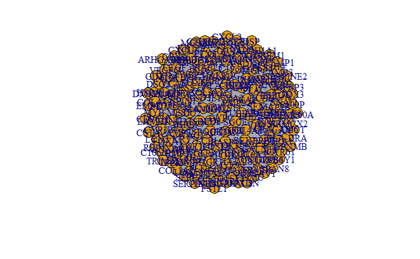

```r
plot(grafo)
```

Vemos algunos datos característicos del grafo como: - Histograma que representa los pesos de las aristas Puede apreciarse que la mayoría de las aristas tienen un peso dentro del rango (0, 0.4) - Media del peso de las aristas: 0.2444883 - Desvación típica: 0.1691008

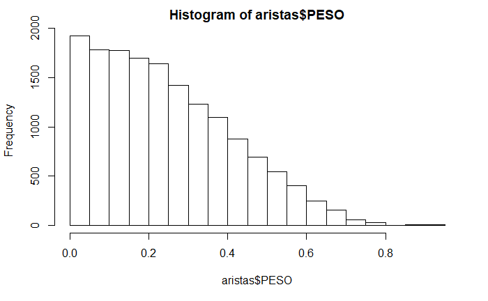

```r
hist(aristas$PESO)
```

```r
mean(aristas$PESO)
```

```
[1] 0.2444883
```

```r
sd(aristas$PESO)
```

```
[1] 0.1691008
```

Probamos varias representaciones gráficas del grafo para intentar verlo con más claridad:

- Círculo

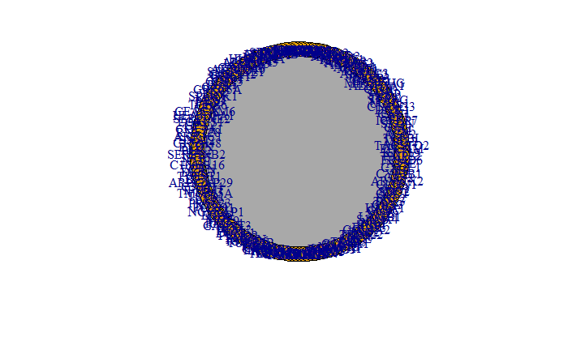

```r
l <- layout_in_circle(grafo)
plot(grafo, layout=l)
```

- Esfera

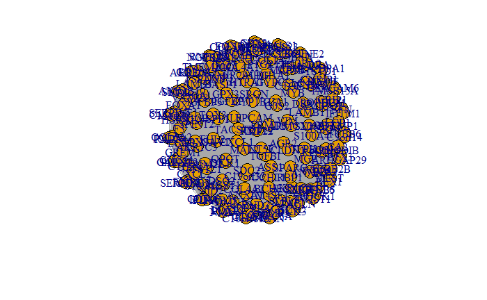

```r
e <- layout_on_sphere(grafo)
plot(grafo, layout=e)
```

- Fruchterman-Reingold

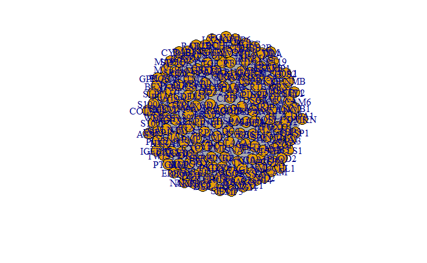

```r
fr <- layout_with_fr(grafo)
plot(grafo, layout=fr)
```

Las visualización del grafo es poco clara debido a la gran cantidad de aristas.

A continuación, lo representamos como mapa de calor a partir de la matriz de adyacencia.

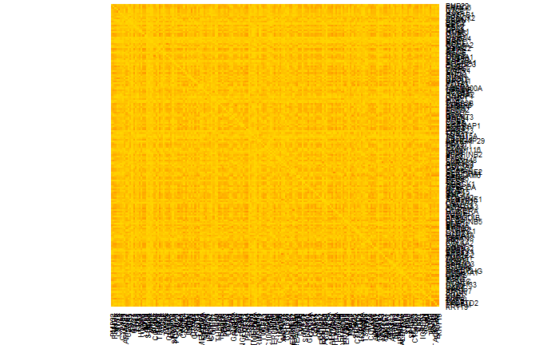

```r
#matriz
netm <- get.adjacency(grafo, attr="PESO", sparse=F)
colnames(netm) <- nodos$NODOS
rownames(netm) <- nodos$NODOS
palf <- colorRampPalette(c("gold", "dark orange"))

heatmap(netm[,177:1], Rowv = NA, Colv = NA, col = palf(100),
        scale="none", margins=c(3,1) )
```

Tras esta primera observacion del grafo, pensamos que su gran tamaño puede dificultar las tareas de clustering y aprendizaje supervisado, por lo que resolvemos podar el grafo a fin de facilitar estas operaciones.

Primero, para entender mejor la red, representamos las aristas en función de su peso. Comprobamos que la mayoría tienen un peso inferior a 0.5.

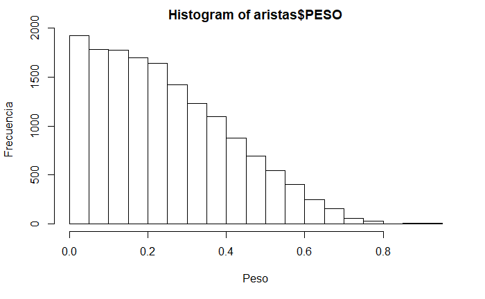

```r
hist(aristas$PESO, xlab = "Peso", ylab = "Frecuencia")
```

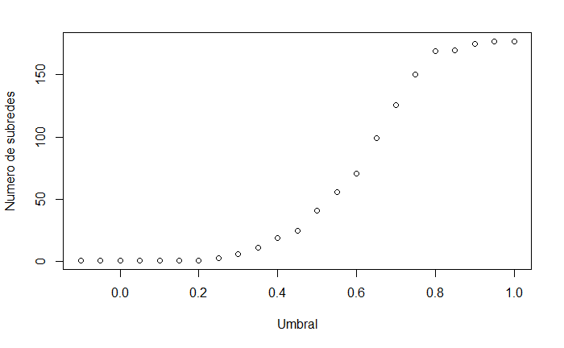

```r
umbral = seq(-0.1 , 1, by=0.05)
no = c(0)
ar = c(0)
i=1
for (x in umbral){
  gf <- delete_edges(grafo, E(grafo)[PESO<x])
  no[i] <- clusters(gf)$no #vector con el numero de clusters
  ar[i] <- edge_density(gf)
  i= i+1
}

plot (x= umbral, y =no, xlab = "Umbral" ,ylab ="Numero de subredes")
```

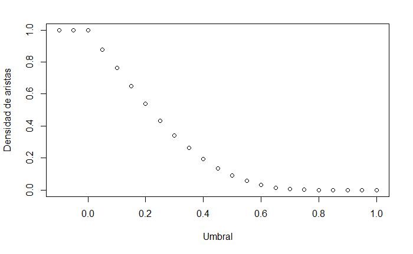

```r
plot (x= umbral, y =ar, xlab = "Umbral" ,ylab ="Densidad de aristas")
```

Visualizando las gráficas, tomamos 0.4 como el umbral de poda de las aristas del grafo. El grafo podado es sobre el que realizaremos las operaciones siguientes.

```r
g4 <- delete_edges(grafo, E(grafo)[PESO<0.4])
```

Tomamos un contacto inicial con este nuevo grafo. Tiene el mismo numero de vertices que el grafo de partida, 177. Sin embargo, el numero de aristas se ha reducido hasta 3007 (un 19% de las aristas del grafo de partida). Viendo la representacion gráfica observamos una mayor claridad.

```r
V(g4)
```

```
+ 177/177 vertices, named, from c2dd04d:
  [1] KRT19     EPCAM     TACSTD2   MAL2      TGFBI     AGR2      VIM       GJA1
  [9] SRGN      IGFBP7    SPP1      CAV1      DKK1      C19orf33  UCHL1     SPARC
 [17] TFPI2     S100P     DSP       CTGF      ALDH1A1   MIR205HG  BASP1     IGFBP3
 [25] SPINT2    AKR1C3    FSTL1     MGST1     ANXA1     TM4SF1    AKR1C2    ANXA3
 [33] RPS4Y1    ESRP1     AMIGO2    NNMT      CAV2      COL1A2    KRT7      IFI27
 [41] TSPAN8    VAMP8     HSPA1A    LCN2      CTHRC1    S100A2    RAB25     SRPX
 [49] PLAC8     MMP1      SERPINB5  PLS3      ARHGDIB   EFEMP1    LUM       MYOF
 [57] HLA-DRA   CYR61     ALDH1A3   LGALS3    CSTA      COL6A3    AKR1B10   SERPINE1
 [65] COL5A2    GNG11     EMP1      GDF15     PLAT      GTSF1     GPRC5A    TNC
 [73] SPOCK1    MEST      PTX3      TUBB6     SFN       CEACAM6   HLA-DPA1  SERPINE2
+ ... omitted several vertices
```

```r
E(g4)
```

```
+ 3007/3007 edges from c2dd04d (vertex names):
 [1] COL4A1  --COL4A2   CAV1    --CAV2     EPCAM   --SPINT2   EPCAM   --MAL2
 [5] ESRP1   --RAB25    AKR1C2  --AKR1C1   EPCAM   --RAB25    MAL2    --SPINT2
 [9] C19orf33--SFN      EPCAM   --ESRP1    CYR61   --GPX8     SPINT2  --RAB25
[13] C19orf33--GPRC5A   SPINT2  --ESRP1    MAL2    --RAB25    MAL2    --ESRP1
[17] MAL2    --DSP      KRT19   --MAL2     C19orf33--ANXA3    MAL2    --SFN
[21] ESRP1   --GALNT3   EPCAM   --DSP      HLA-DRA --HLA-DPA1 MYOF    --GPRC5A
[25] EPCAM   --SFN      CAV2    --MYOF     RAB25   --GALNT3   AKR1C3  --AKR1C1
[29] SERPINB5--SFN      MAL2    --DSG2     CTGF    --CYR61    TACSTD2 --SFN
[33] MYOF    --PRSS23   KRT19   --EPCAM    KRT19   --C19orf33 VIM     --EMP3
[37] FSTL1   --GPX8     C19orf33--LAMB3    CAV1    --CYR61    SPINT2  --SFN
+ ... omitted several edges
```

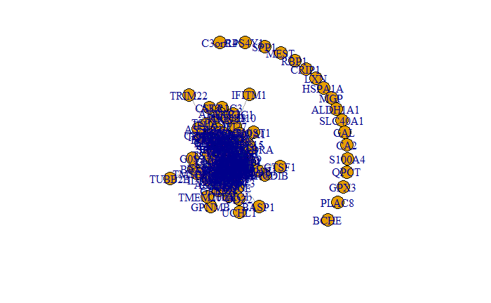

```r
plot(g4)
```

Observamos de nuevo la matriz de adyacencia. Cuenta con muchas mas zonas de color amarillo claro, que denota una menor relacion entre los nodos presentes.

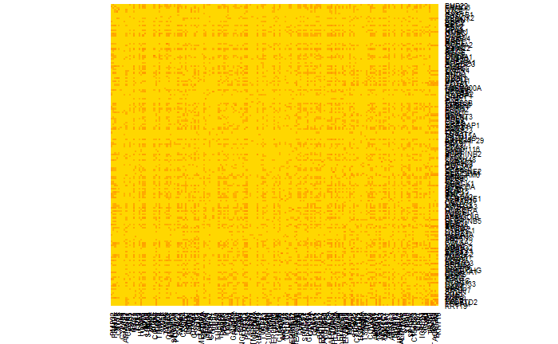

```r
netm <- get.adjacency(g4, attr="PESO", sparse=F)
colnames(netm) <- nodos$NODOS
rownames(netm) <- nodos$NODOS
palf <- colorRampPalette(c("gold", "dark orange"))

heatmap(netm[,177:1], Rowv = NA, Colv = NA, col = palf(100),
        scale="none", margins=c(3,1) )
```

Matriz de distancias

```r
distM <- shortest.paths(g4, weights = E(g4)$PESO)
distM
```

[output not shown]

[output cut: 78 more lines]

[output not shown]